# initial_survey

Autogenerated data summary from dataMaid

2023-10-06 09:11:03.212623

# Data report overview

The dataset examined has the following dimensions:

| Feature | Result |
| --- | --- |
| Number of observations | 3952 |
| Number of variables | 75 |

### Checks performed

The following variable checks were performed, depending on the data type of each variable:

|  | character | factor | labelled | haven labelled | numeric | integer | logical | Date |
| --- | --- | --- | --- | --- | --- | --- | --- | --- |
| Identify miscoded missing values | × | × | × | × | × | × |  | × |
| Identify prefixed and suffixed whitespace | × | × | × | × |  |  |  |  |
| Identify levels with < 6 obs. | × | × | × | × |  |  |  |  |
| Identify case issues | × | × | × | × |  |  |  |  |
| Identify misclassified numeric or integer variables | × | × | × | × |  |  |  |  |
| Identify outliers |  |  |  |  | × | × |  | × |

Please note that all numerical values in the following have been rounded to 2 decimals.

# Summary table

|  | Variable class | # unique values | Missing observations | Any problems? |
| --- | --- | --- | --- | --- |
| X | integer | 3952 | 0.00 % |  |
| connection_period_initial | numeric | 7 | 63.99 % |  |
| renewvia_id | character | 1191 | 0.00 % | × |
| country | numeric | 3 | 0.08 % |  |
| nigeria_community | numeric | 9 | 53.57 % | × |
| kenya_community | numeric | 13 | 46.46 % |  |
| age | character | 92 | 0.00 % | × |
| gender | numeric | 3 | 0.10 % |  |
| occupation | numeric | 18 | 49.67 % |  |
| primary_provider | numeric | 3 | 0.91 % |  |
| primary_provider_occupation | character | 22 | 0.00 % | × |
| employement_type | numeric | 6 | 2.51 % |  |
| avg_household_income | integer | 200 | 5.49 % | × |
| household_headcount | integer | 43 | 1.97 % | × |
| adult_headcount | integer | 33 | 1.77 % | × |
| girls_headcount | integer | 23 | 6.48 % | × |
| boys_headcount | integer | 25 | 6.35 % | × |
| girls_age | character | 790 | 0.00 % | × |
| boys_age | character | 809 | 0.00 % | × |
| girls_schooling | integer | 24 | 12.93 % | × |
| girls_unschooled_reasons | character | 10 | 0.00 % | × |
| boys_schooling | integer | 20 | 13.01 % | × |
| boys_unschooled_reasons | numeric | 9 | 12.47 % |  |
| household_business_owners | character | 7 | 0.00 % | × |
| minigrid_signup_primary_reason | character | 83 | 0.00 % | × |
| minigrid_signup_secondary_reason | character | 11 | 0.00 % | × |
| power_sources | character | 123 | 0.00 % | × |
| power_sources_usage | numeric | 5 | 6.50 % |  |
| power_sources_primary | character | 19 | 0.00 % | × |
| appliances_count | integer | 23 | 10.43 % | × |
| cellphones_count | integer | 21 | 51.85 % | × |
| appliances_type | character | 334 | 0.00 % | × |
| appliances_explain | character | 92 | 0.00 % | × |
| appliances_addition_type | character | 610 | 0.00 % | × |
| light_hours_current | integer | 24 | 12.02 % | × |
| light_primary_sources | character | 19 | 0.00 % | × |
| kerosene_lamps_count | integer | 12 | 18.07 % | × |
| kerosene_lamp_usage_time | numeric | 5 | 18.98 % |  |
| kerosene_lamps_cost | numeric | 6 | 19.28 % |  |
| cooking_energy_sources | numeric | 7 | 0.73 % | × |
| cooking_fuel_collection_time | numeric | 5 | 4.81 % |  |
| cooking_fuel_responsible | character | 42 | 0.00 % | × |
| cooking_energy_cost | numeric | 6 | 7.82 % |  |
| applicances_charging_sources | numeric | 7 | 1.95 % | × |
| applicances_charging_cost | numeric | 6 | 5.19 % |  |
| feel_safe_dark | numeric | 6 | 1.06 % |  |
| community_lights | character | 6 | 0.00 % | × |
| home_exterior_lights | numeric | 3 | 1.37 % |  |
| feel_safe_if_exterior_lights | numeric | 6 | 0.35 % |  |
| feel_unsafe_reasons | numeric | 7 | 0.38 % | × |
| phone_charge_location | numeric | 5 | 1.09 % |  |
| phone_charge_frequency | numeric | 5 | 2.86 % |  |
| phone_charge_cost | character | 7 | 0.00 % | × |
| phone_charge_travel_distance | numeric | 6 | 8.45 % |  |
| water_source | character | 6 | 0.00 % | × |
| clean_drinking_water | numeric | 3 | 3.47 % |  |
| clean_drinking_water_source | numeric | 5 | 41.30 % |  |
| clean_water_source | character | 27 | 0.00 % | × |
| water_collection_travel_distance | numeric | 6 | 8.96 % |  |
| water_collection_time | numeric | 6 | 10.17 % |  |
| water_collection_responsible | numeric | 5 | 9.41 % |  |
| avg_person_age_water_collection | numeric | 7 | 11.23 % | × |
| water_cost | character | 7 | 0.00 % | × |
| other_household_activities | character | 85 | 0.00 % | × |
| clinic_travel_distance | numeric | 6 | 52.48 % |  |
| clinic_electricity_access | numeric | 3 | 50.68 % |  |
| clinic_refrigeration_access | numeric | 3 | 51.01 % |  |
| end_date | character | 83 | 0.00 % | × |
| customerAccountNumber | integer | 950 | 74.60 % |  |
| tariff | character | 4 | 0.00 % | × |
| occupation_secondary_provider | character | 20 | 0.00 % | × |
| community_clean_water_source | character | 80 | 0.00 % | × |
| business_owners_count | integer | 3 | 0.00 % |  |
| business_owners_female | integer | 2 | 0.00 % |  |
| appliances_type_count | integer | 9 | 0.00 % |  |

# Variable list

## X

| Feature | Result |
| --- | --- |
| Variable type | integer |
| Number of missing obs. | 0 (0 %) |
| Number of unique values | 3952 |
| Median | 1975.5 |
| 1st and 3rd quartiles | 987.75; 2963.25 |
| Min. and max. | 0; 3951 |

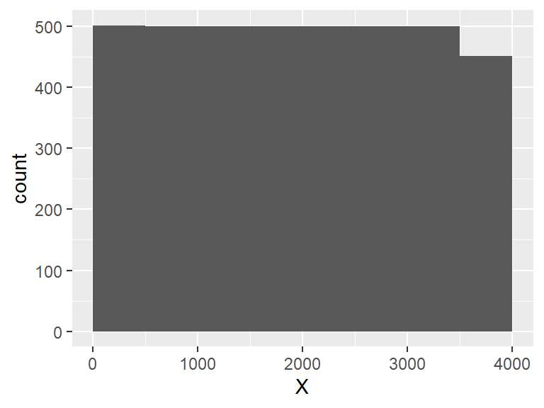

## connection_period_initial

| Feature | Result |
| --- | --- |
| Variable type | numeric |
| Number of missing obs. | 2529 (63.99 %) |
| Number of unique values | 6 |
| Median | 3 |
| 1st and 3rd quartiles | 1; 4 |
| Min. and max. | 1; 6 |

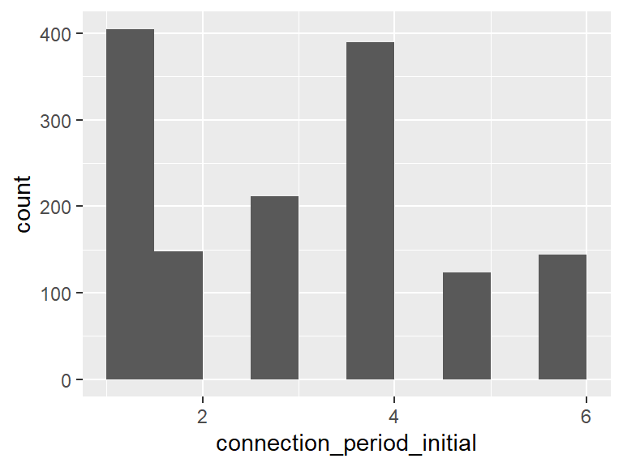

## renewvia_id

| Feature | Result |
| --- | --- |
| Variable type | character |
| Number of missing obs. | 0 (0 %) |
| Number of unique values | 1191 |
| Mode | “” |

[figure not shown]

- The following suspected missing value codes enter as regular values: "".
- Note that the following levels have at most five observations: "115183", "131110", "131117", "131120", "131122", …, "rn2708", "rn2819", "rn2823", "rn2825", "rn2831" (1179 values omitted).

## country

- Note that this variable is treated as a factor variable below, as it only takes a few unique values.

| Feature | Result |
| --- | --- |
| Variable type | numeric |
| Number of missing obs. | 3 (0.08 %) |
| Number of unique values | 2 |
| Mode | “2” |
| Reference category | 1 |

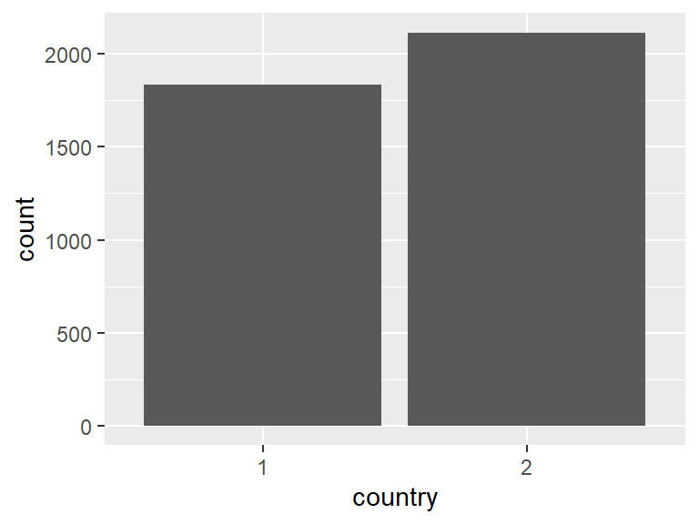

## nigeria_community

| Feature | Result |
| --- | --- |
| Variable type | numeric |
| Number of missing obs. | 2117 (53.57 %) |
| Number of unique values | 8 |
| Median | 5 |
| 1st and 3rd quartiles | 3; 9 |
| Min. and max. | 1; 9 |

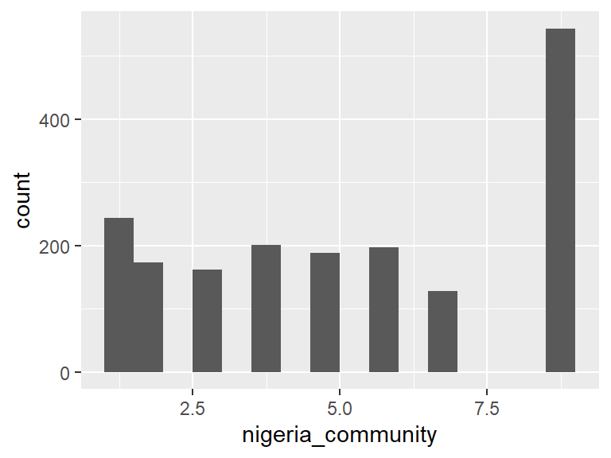

- The following suspected missing value codes enter as regular values: "9".

## kenya_community

| Feature | Result |
| --- | --- |
| Variable type | numeric |
| Number of missing obs. | 1836 (46.46 %) |
| Number of unique values | 12 |
| Median | 3 |
| 1st and 3rd quartiles | 1; 6 |
| Min. and max. | 1; 14 |

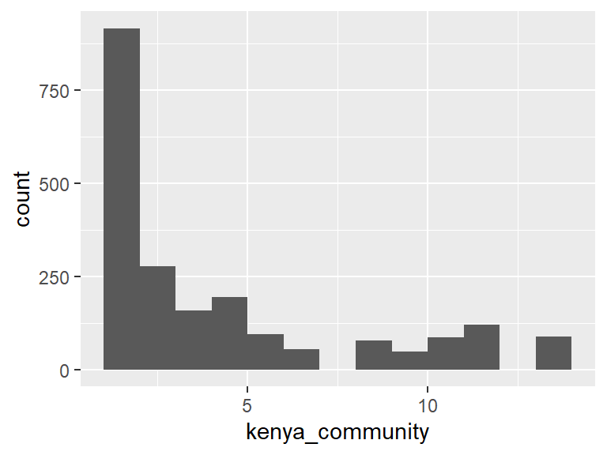

## age

| Feature | Result |
| --- | --- |
| Variable type | character |
| Number of missing obs. | 0 (0 %) |
| Number of unique values | 92 |
| Mode | “35” |

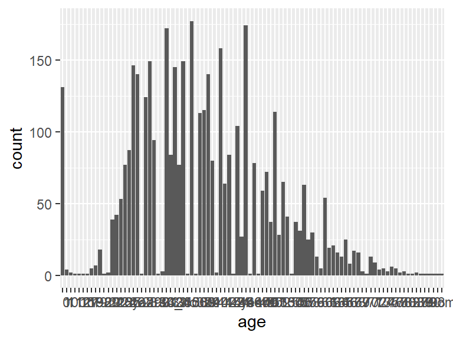

- The following suspected missing value codes enter as regular values: "", "88".
- Note that the following levels have at most five observations: "0", "1", "100", "112", "12", …, "88", "89", "90", "93", "ikom" (27 values omitted).

## gender

- Note that this variable is treated as a factor variable below, as it only takes a few unique values.

| Feature | Result |
| --- | --- |
| Variable type | numeric |
| Number of missing obs. | 4 (0.1 %) |
| Number of unique values | 2 |
| Mode | “2” |
| Reference category | 1 |

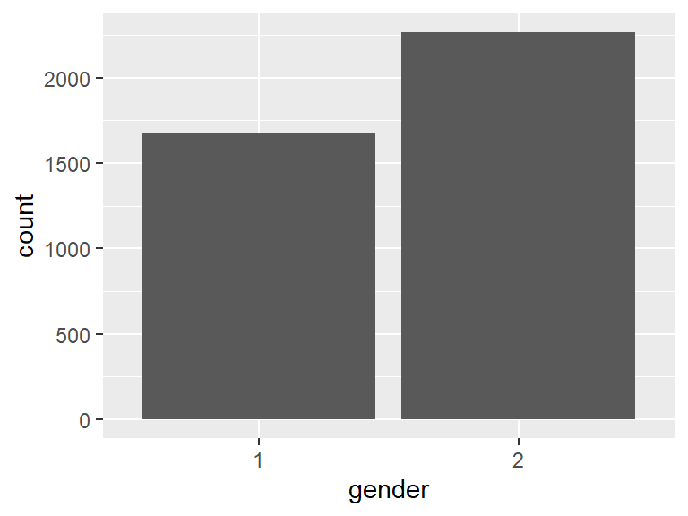

## occupation

| Feature | Result |
| --- | --- |
| Variable type | numeric |
| Number of missing obs. | 1963 (49.67 %) |
| Number of unique values | 17 |
| Median | 4 |
| 1st and 3rd quartiles | 1; 8 |
| Min. and max. | 1; 17 |

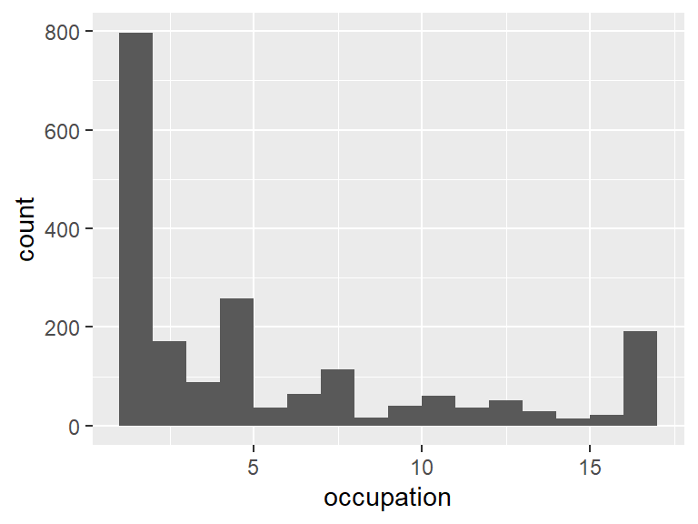

## primary_provider

- Note that this variable is treated as a factor variable below, as it only takes a few unique values.

| Feature | Result |
| --- | --- |
| Variable type | numeric |
| Number of missing obs. | 36 (0.91 %) |
| Number of unique values | 2 |
| Mode | “1” |
| Reference category | 0 |

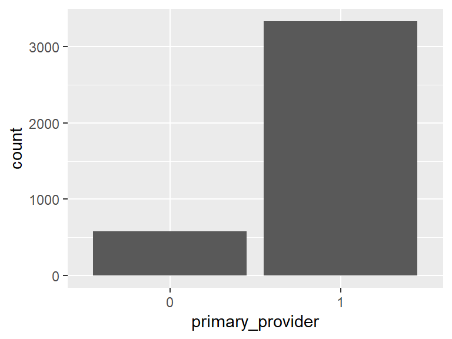

## primary_provider_occupation

| Feature | Result |
| --- | --- |
| Variable type | character |
| Number of missing obs. | 0 (0 %) |
| Number of unique values | 22 |
| Mode | “1” |

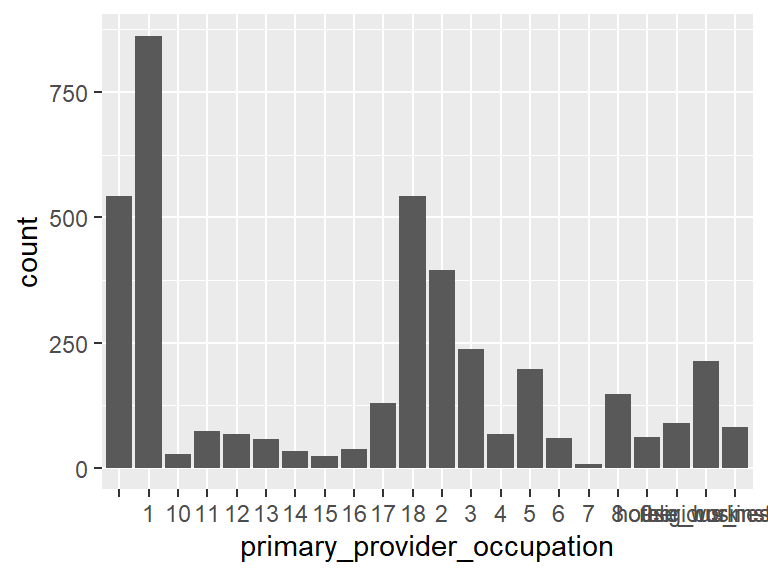

- The following suspected missing value codes enter as regular values: "", "8", "9".

## employement_type

- Note that this variable is treated as a factor variable below, as it only takes a few unique values.

| Feature | Result |
| --- | --- |
| Variable type | numeric |
| Number of missing obs. | 99 (2.51 %) |
| Number of unique values | 5 |
| Mode | “1” |
| Reference category | 1 |

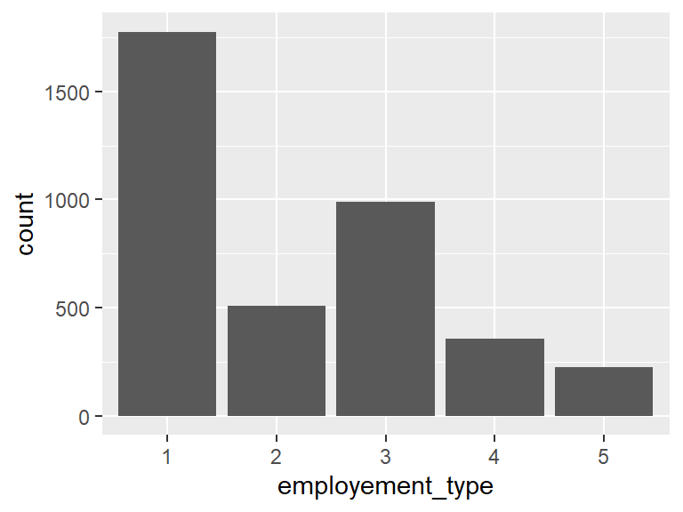

## avg_household_income

| Feature | Result |
| --- | --- |
| Variable type | integer |
| Number of missing obs. | 217 (5.49 %) |
| Number of unique values | 199 |
| Median | 10500 |
| 1st and 3rd quartiles | 3000; 30000 |
| Min. and max. | 0; 5e+05 |

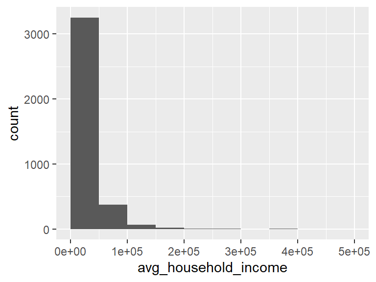

- Note that the following possible outlier values were detected: "295000", "3e+05", "300010", "350000", "350003", "390000", "4e+05", "5e+05".

## household_headcount

| Feature | Result |
| --- | --- |
| Variable type | integer |
| Number of missing obs. | 78 (1.97 %) |
| Number of unique values | 42 |
| Median | 5 |
| 1st and 3rd quartiles | 4; 7 |
| Min. and max. | 0; 30000 |

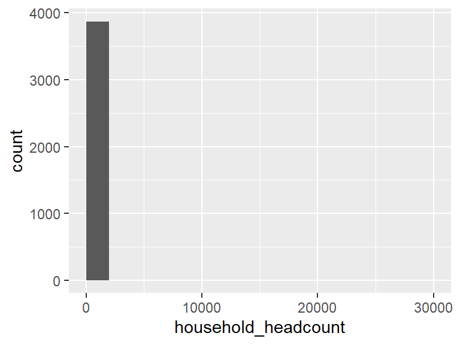

- Note that the following possible outlier values were detected: "0", "1", "16", "17", "18", …, "120", "130", "150", "20000", "30000" (18 values omitted).

## adult_headcount

| Feature | Result |
| --- | --- |
| Variable type | integer |
| Number of missing obs. | 70 (1.77 %) |
| Number of unique values | 32 |
| Median | 2 |
| 1st and 3rd quartiles | 2; 3 |
| Min. and max. | 0; 100 |

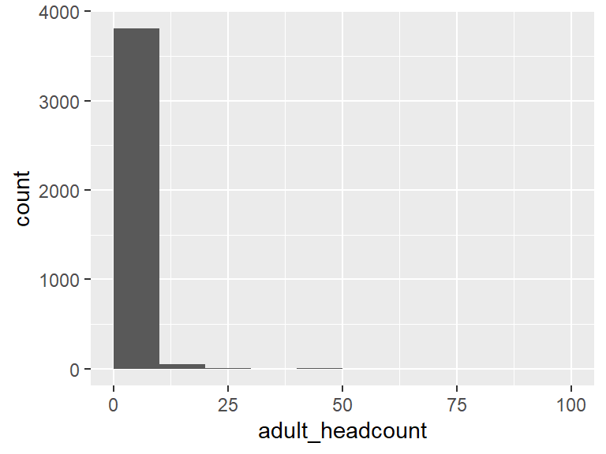

- Note that the following possible outlier values were detected: "0", "1", "40", "42", "50", "60", "70", "80", "90", "100".

## girls_headcount

| Feature | Result |
| --- | --- |
| Variable type | integer |
| Number of missing obs. | 256 (6.48 %) |
| Number of unique values | 22 |
| Median | 2 |
| 1st and 3rd quartiles | 1; 3 |
| Min. and max. | 0; 70 |

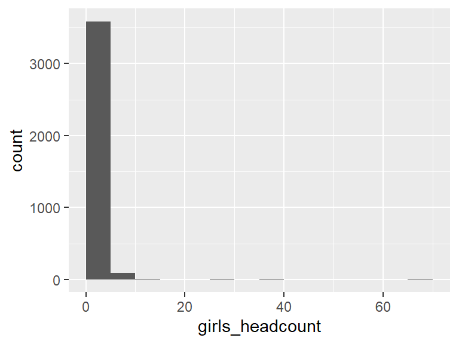

- Note that the following possible outlier values were detected: "7", "8", "9", "10", "11", …, "30", "40", "43", "50", "70" (5 values omitted).

## boys_headcount

| Feature | Result |
| --- | --- |
| Variable type | integer |
| Number of missing obs. | 251 (6.35 %) |
| Number of unique values | 24 |
| Median | 2 |
| 1st and 3rd quartiles | 1; 3 |
| Min. and max. | 0; 70 |

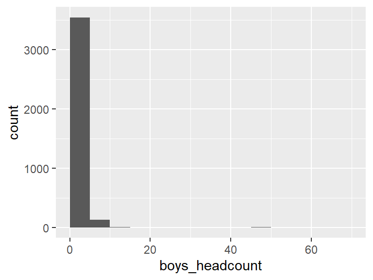

- Note that the following possible outlier values were detected: "7", "8", "9", "10", "11", …, "44", "50", "60", "63", "70" (7 values omitted).

## girls_age

| Feature | Result |
| --- | --- |
| Variable type | character |
| Number of missing obs. | 0 (0 %) |
| Number of unique values | 790 |
| Mode | “older_than_16;” |

[figure not shown]

- The following suspected missing value codes enter as regular values: "", "8", "9".
- Note that the following levels have at most five observations: "1", "1;10;14;", "1;10;15;older_than_16;", "1;10;16;older_than_16;", "1;11;", …, "9;15;", "9;15;older_than_16;", "9;16;", "9;16;older_than_16", "9;older_than_16" (685 values omitted).

## boys_age

| Feature | Result |
| --- | --- |
| Variable type | character |
| Number of missing obs. | 0 (0 %) |
| Number of unique values | 809 |
| Mode | “older_than_16;” |

[figure not shown]

- The following suspected missing value codes enter as regular values: "", "8", "9".
- Note that the following levels have at most five observations: "1", "1;10", "1;10;12;", "1;10;14;", "1;10;14;16;", …, "9;16;", "9;16;older_than_16", "9;16;older_than_16;", "9;older_than_16", "9;older_than_16;" (718 values omitted).

## girls_schooling

| Feature | Result |
| --- | --- |
| Variable type | integer |
| Number of missing obs. | 511 (12.93 %) |
| Number of unique values | 23 |
| Median | 1 |
| 1st and 3rd quartiles | 1; 2 |
| Min. and max. | 0; 70 |

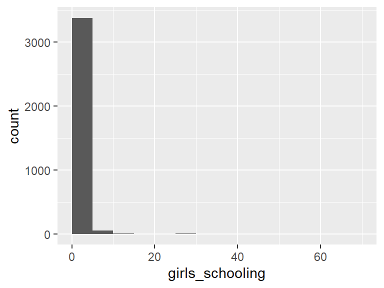

- Note that the following possible outlier values were detected: "0", "9", "10", "11", "12", …, "36", "40", "50", "60", "70" (5 values omitted).

## girls_unschooled_reasons

| Feature | Result |
| --- | --- |
| Variable type | character |
| Number of missing obs. | 0 (0 %) |
| Number of unique values | 10 |
| Mode | “they_all_attend_school” |

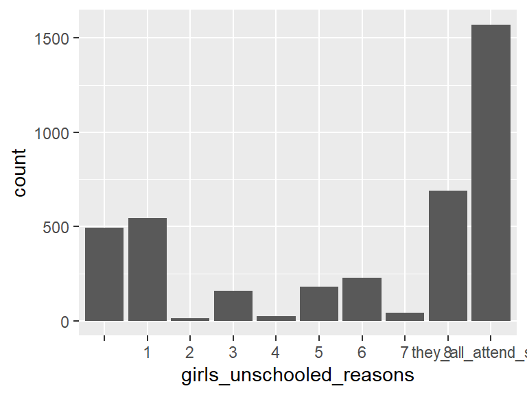

- The following suspected missing value codes enter as regular values: "", "8".

## boys_schooling

| Feature | Result |
| --- | --- |
| Variable type | integer |
| Number of missing obs. | 514 (13.01 %) |
| Number of unique values | 19 |
| Median | 2 |
| 1st and 3rd quartiles | 1; 3 |
| Min. and max. | 0; 70 |

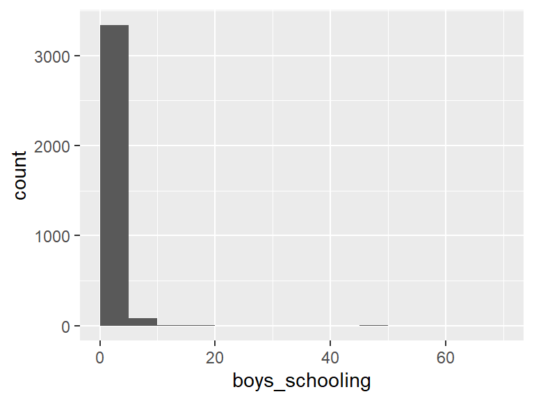

- Note that the following possible outlier values were detected: "7", "8", "9", "11", "12", …, "30", "40", "50", "60", "70" (2 values omitted).

## boys_unschooled_reasons

| Feature | Result |
| --- | --- |
| Variable type | numeric |
| Number of missing obs. | 493 (12.47 %) |
| Number of unique values | 8 |
| Median | 1 |
| 1st and 3rd quartiles | 1; 6 |
| Min. and max. | 1; 8 |

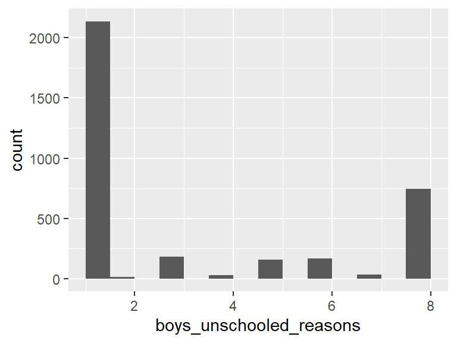

## household_business_owners

| Feature | Result |
| --- | --- |
| Variable type | character |
| Number of missing obs. | 0 (0 %) |
| Number of unique values | 7 |
| Mode | “” |

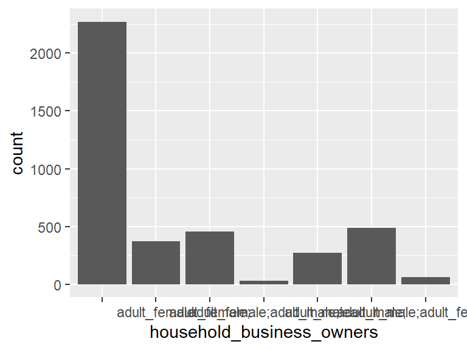

- The following suspected missing value codes enter as regular values: "".

## minigrid_signup_primary_reason

| Feature | Result |
| --- | --- |
| Variable type | character |
| Number of missing obs. | 0 (0 %) |
| Number of unique values | 83 |
| Mode | “1” |

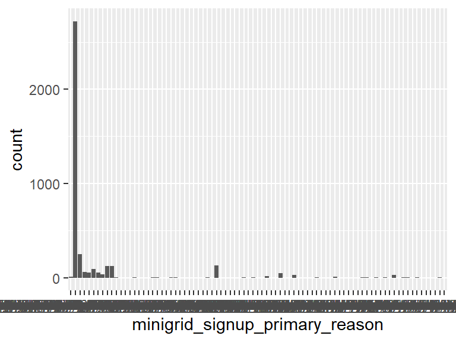

- The following suspected missing value codes enter as regular values: "", "8", "9".
- Note that the following levels have at most five observations: "ability_to_charge_mobile_phone(s;increased_hours_of_productivity_business_studying_etc", "ability_to_charge_mobile_phone(s;possibility_to_purchase_a_tv", "ability_to_charge_mobile_phone(s;safety_of_persons_physical", "ability_to_charge_mobile_phone(s;safety_of_persons_physical;security_of_property_home_possessions;ability_to_earn_more_money", "ability_to_charge_mobile_phone(s;security_of_property_home_possessions", …, "security_of_property_home_possessions;ability_to_save_more_money;increased_hours_of_productivity_business_studying_etc", "security_of_property_home_possessions;ability_to_save_more_money;increased_hours_of_productivity_business_studying_etc;ability_to_start_a_new_business", "security_of_property_home_possessions;ability_to_start_a_new_business", "security_of_property_home_possessions;increased_hours_of_productivity_business_studying_etc", "security_of_property_home_possessions;increased_hours_of_productivity_business_studying_etc;ability_to_start_a_new_business" (53 values omitted).

## minigrid_signup_secondary_reason

| Feature | Result |
| --- | --- |
| Variable type | character |
| Number of missing obs. | 0 (0 %) |
| Number of unique values | 11 |
| Mode | “2” |

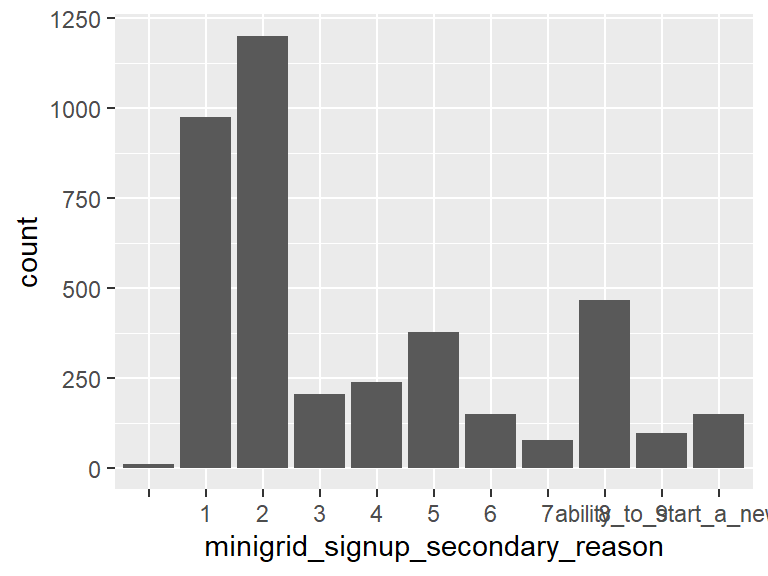

- The following suspected missing value codes enter as regular values: "", "8", "9".

## power_sources

| Feature | Result |
| --- | --- |
| Variable type | character |
| Number of missing obs. | 0 (0 %) |
| Number of unique values | 123 |
| Mode | “solar_home_kit;” |

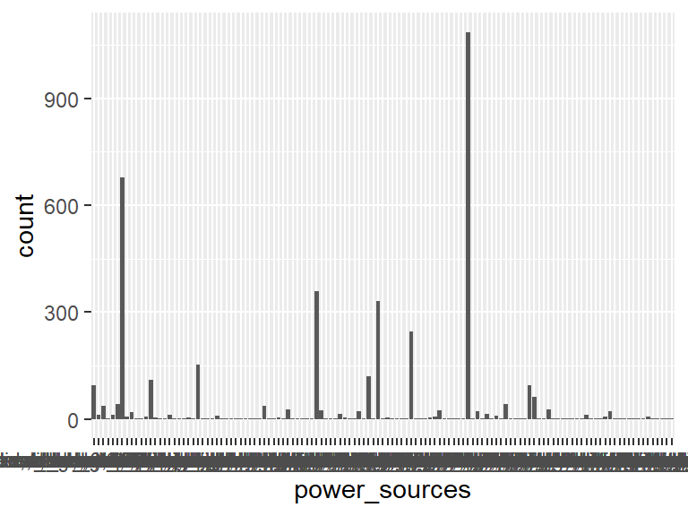

- The following suspected missing value codes enter as regular values: "", "8".
- Note that the following levels have at most five observations: "1;kerosene_lamp;", "7", "8", "candles;charcoal;", "candles;charcoal;kerosene_lamp;", …, "torch;solar_home_kit;", "torch_;", "torches_;", "use_public_light_to_read;", "yes;kerosene_lamp;" (77 values omitted).

## power_sources_usage

- Note that this variable is treated as a factor variable below, as it only takes a few unique values.

| Feature | Result |
| --- | --- |
| Variable type | numeric |
| Number of missing obs. | 257 (6.5 %) |
| Number of unique values | 4 |
| Mode | “2” |
| Reference category | 1 |

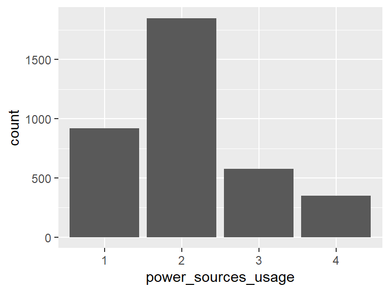

## power_sources_primary

| Feature | Result |
| --- | --- |
| Variable type | character |
| Number of missing obs. | 0 (0 %) |
| Number of unique values | 19 |
| Mode | “7” |

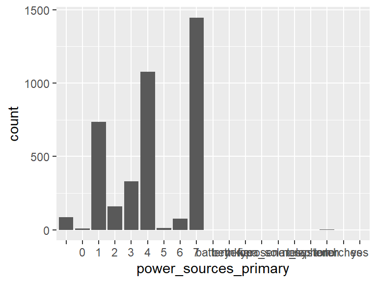

- The following suspected missing value codes enter as regular values: "".
- Note that the following levels have at most five observations: "battery", "bettery", "fire", "kerosene", "mkopa_solar_system", "none", "telephone", "torch", "torches", "yes".

## appliances_count

| Feature | Result |
| --- | --- |
| Variable type | integer |
| Number of missing obs. | 412 (10.43 %) |
| Number of unique values | 22 |
| Median | 2 |
| 1st and 3rd quartiles | 2; 3 |
| Min. and max. | 0; 300 |

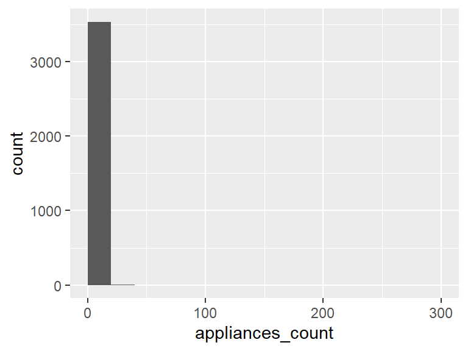

- Note that the following possible outlier values were detected: "0", "1", "10", "11", "12", …, "32", "33", "59", "69", "300" (4 values omitted).

## cellphones_count

| Feature | Result |
| --- | --- |
| Variable type | integer |
| Number of missing obs. | 2049 (51.85 %) |
| Number of unique values | 20 |
| Median | 2 |
| 1st and 3rd quartiles | 2; 3 |
| Min. and max. | 0; 50 |

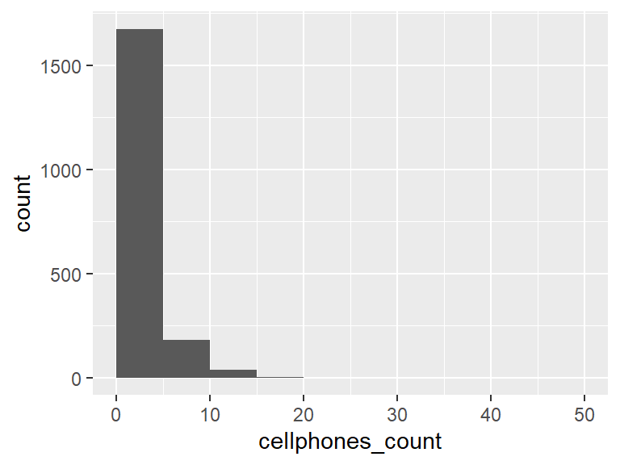

- Note that the following possible outlier values were detected: "0", "1", "50".

## appliances_type

| Feature | Result |
| --- | --- |
| Variable type | character |
| Number of missing obs. | 0 (0 %) |
| Number of unique values | 334 |
| Mode | “lights;” |

[figure not shown]

- The following suspected missing value codes enter as regular values: "", "8".
- Note that the following levels have at most five observations: "3", "7", "8", "cell_phone_charge;fan", "cell_phone_charger;fan;", …, "television;radio;lights;fan;other", "television;radio;lights;other;", "television;radio;lights;other;cell_phone_charger;", "television;refrigerator", "television;stovetop;computer;radio;lights;fan;cell_phone_charger;" (235 values omitted).

## appliances_explain

| Feature | Result |
| --- | --- |
| Variable type | character |
| Number of missing obs. | 0 (0 %) |
| Number of unique values | 92 |
| Mode | “” |

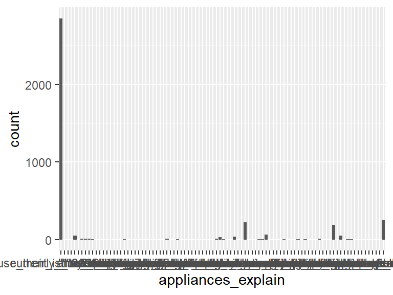

- The following suspected missing value codes enter as regular values: "".
- Note that the following levels have at most five observations: "“““", "**", "_none", "00", "4", …, "torch", "tv_radio", "water_heater_blow_drier", "y6", "yea" (65 values omitted).

## appliances_addition_type

| Feature | Result |
| --- | --- |
| Variable type | character |
| Number of missing obs. | 0 (0 %) |
| Number of unique values | 610 |
| Mode | “other;” |

[figure not shown]

- The following suspected missing value codes enter as regular values: "".
- Note that the following levels have at most five observations: "cell_phone_charger;computer;lights;radio;", "cell_phone_charger;fan;", "cell_phone_charger;fan;computer;television;stovetop;", "cell_phone_charger;fan;lights;", "cell_phone_charger;fan;lights;computer;television;stovetop;other;", …, "television_radio_lights_fan_cell_phone_charger_refrigerator_microwave", "television_radio_lights_fan_refrigerator_microwave", "television_radio_lights_microwave", "television_radio_lights_refrigerator", "television_radio_refrigerator" (492 values omitted).

## light_hours_current

| Feature | Result |
| --- | --- |
| Variable type | integer |
| Number of missing obs. | 475 (12.02 %) |
| Number of unique values | 23 |
| Median | 4 |
| 1st and 3rd quartiles | 2; 6 |
| Min. and max. | 0; 46 |

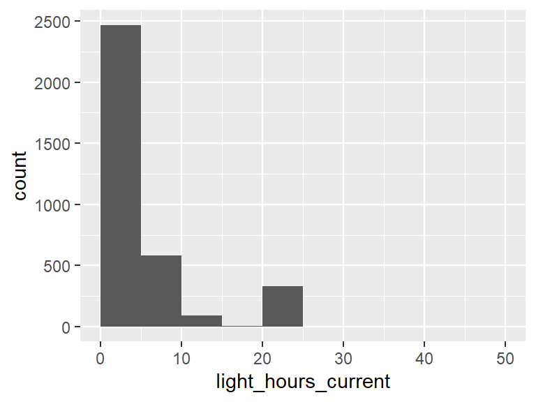

- Note that the following possible outlier values were detected: "0", "24", "25", "46".

## light_primary_sources

| Feature | Result |
| --- | --- |
| Variable type | character |
| Number of missing obs. | 0 (0 %) |
| Number of unique values | 19 |
| Mode | “electric_source_phone_light_electric_lightbulb;” |

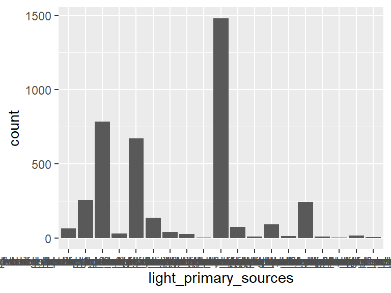

- The following suspected missing value codes enter as regular values: "".
- Note that the following levels have at most five observations: "battery_powered_flashlighttorch;kerosene_source_kerosene_lamps;electric_source_phone_light_electric_lightbulb;", "kerosene_source_kerosene_lamps;battery_powered_flashlighttorch;electric_source_phone_light_electric_lightbulb;", "kerosene_source_kerosene_lamps;electric_source_phone_light_electric_lightbulb;battery_powered_flashlighttorch;".

## kerosene_lamps_count

| Feature | Result |
| --- | --- |
| Variable type | integer |
| Number of missing obs. | 714 (18.07 %) |
| Number of unique values | 11 |
| Median | 1 |
| 1st and 3rd quartiles | 0; 2 |
| Min. and max. | 0; 30 |

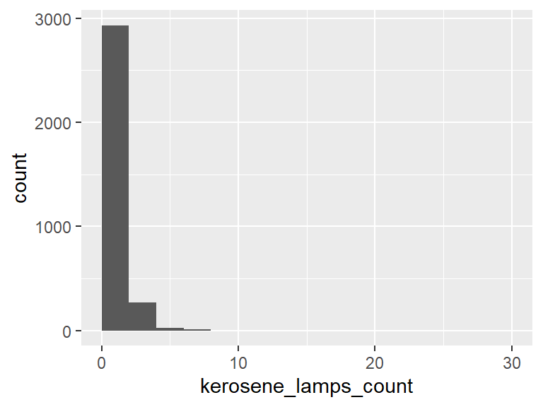

- Note that the following possible outlier values were detected: "6", "7", "8", "11", "30".

## kerosene_lamp_usage_time

- Note that this variable is treated as a factor variable below, as it only takes a few unique values.

| Feature | Result |
| --- | --- |
| Variable type | numeric |
| Number of missing obs. | 750 (18.98 %) |
| Number of unique values | 4 |
| Mode | “1” |
| Reference category | 1 |

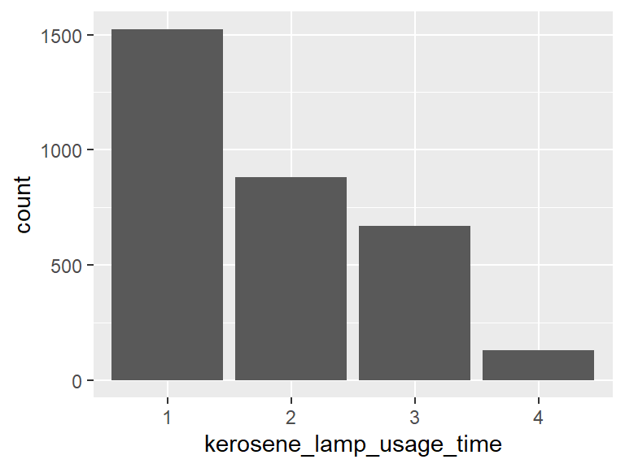

## kerosene_lamps_cost

- Note that this variable is treated as a factor variable below, as it only takes a few unique values.

| Feature | Result |
| --- | --- |
| Variable type | numeric |
| Number of missing obs. | 762 (19.28 %) |
| Number of unique values | 5 |
| Mode | “1” |
| Reference category | 1 |

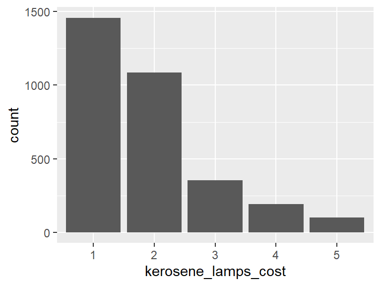

## cooking_energy_sources

| Feature | Result |
| --- | --- |
| Variable type | numeric |
| Number of missing obs. | 29 (0.73 %) |
| Number of unique values | 6 |
| Median | 3 |
| 1st and 3rd quartiles | 1; 3 |
| Min. and max. | 1; 6 |

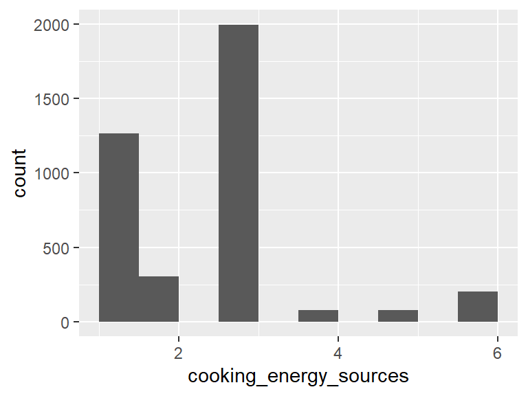

- Note that the following possible outlier values were detected: "4", "5", "6".

## cooking_fuel_collection_time

- Note that this variable is treated as a factor variable below, as it only takes a few unique values.

| Feature | Result |
| --- | --- |
| Variable type | numeric |
| Number of missing obs. | 190 (4.81 %) |
| Number of unique values | 4 |
| Mode | “1” |
| Reference category | 1 |

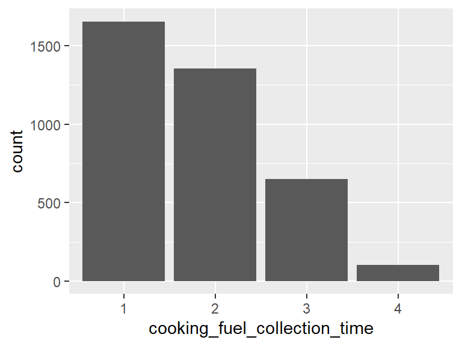

## cooking_fuel_responsible

| Feature | Result |
| --- | --- |
| Variable type | character |
| Number of missing obs. | 0 (0 %) |
| Number of unique values | 42 |
| Mode | “adult_female;” |

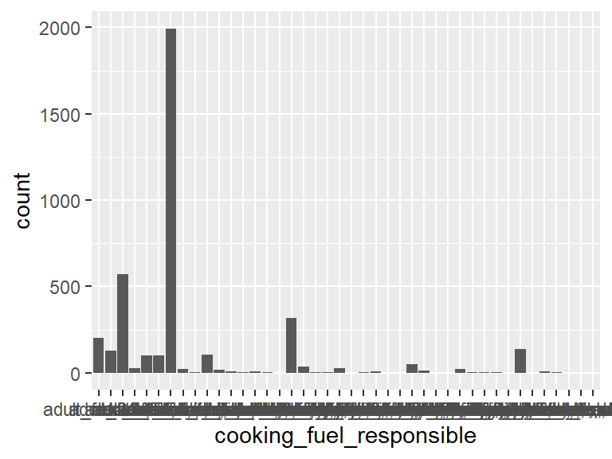

- The following suspected missing value codes enter as regular values: "".
- Note that the following levels have at most five observations: "adult_female;adult_male;whole_family;", "adult_female;child_male;child_female;", "adult_female;whole_family;adult_male;", "adult_female;whole_family;child_female;", "adult_male;adult_female;child_female;", …, "whole_family;adult_female;", "whole_family;adult_male;adult_female;", "whole_family;child_female;adult_female;", "whole_family;child_male;adult_female;adult_male;", "whole_family;child_male;adult_male;adult_female;" (11 values omitted).

## cooking_energy_cost

- Note that this variable is treated as a factor variable below, as it only takes a few unique values.

| Feature | Result |
| --- | --- |
| Variable type | numeric |
| Number of missing obs. | 309 (7.82 %) |
| Number of unique values | 5 |
| Mode | “2” |
| Reference category | 1 |

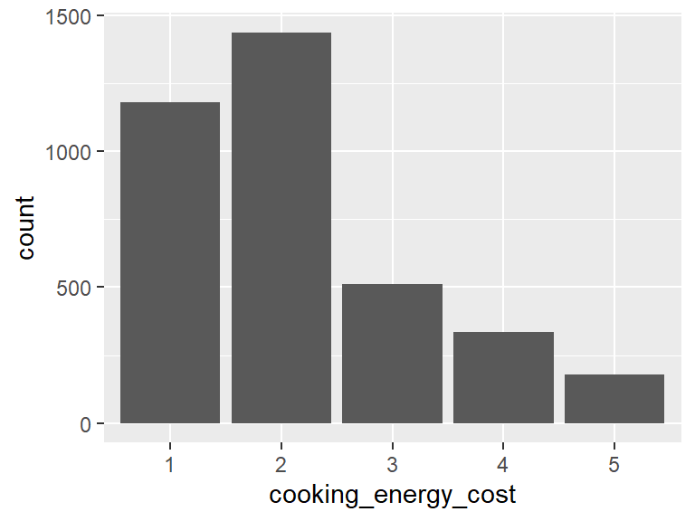

## applicances_charging_sources

| Feature | Result |
| --- | --- |
| Variable type | numeric |
| Number of missing obs. | 77 (1.95 %) |
| Number of unique values | 6 |
| Median | 2 |
| 1st and 3rd quartiles | 2; 5 |
| Min. and max. | 1; 6 |

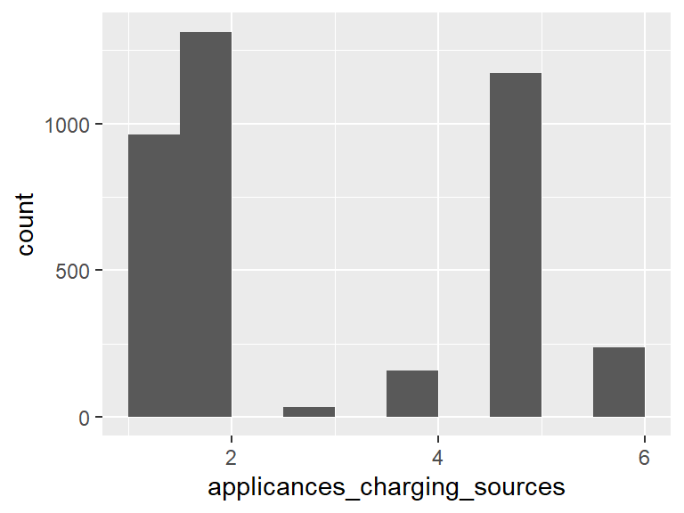

- Note that the following possible outlier values were detected: "1".

## applicances_charging_cost

- Note that this variable is treated as a factor variable below, as it only takes a few unique values.

| Feature | Result |
| --- | --- |
| Variable type | numeric |
| Number of missing obs. | 205 (5.19 %) |
| Number of unique values | 5 |
| Mode | “2” |
| Reference category | 1 |

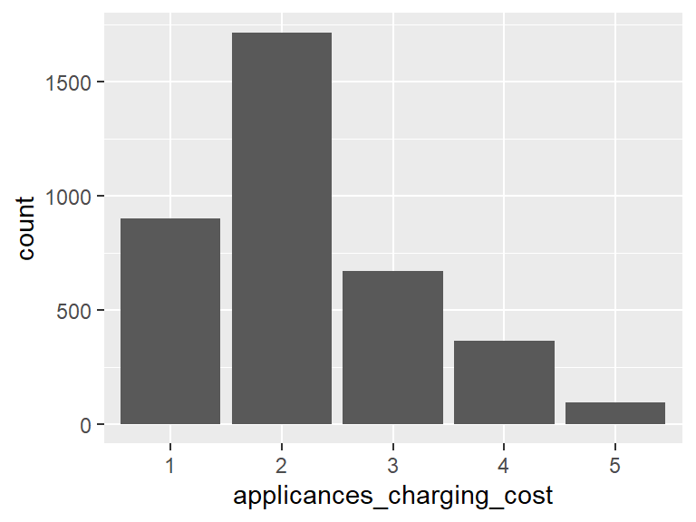

## feel_safe_dark

- Note that this variable is treated as a factor variable below, as it only takes a few unique values.

| Feature | Result |
| --- | --- |
| Variable type | numeric |
| Number of missing obs. | 42 (1.06 %) |
| Number of unique values | 5 |
| Mode | “5” |
| Reference category | 1 |

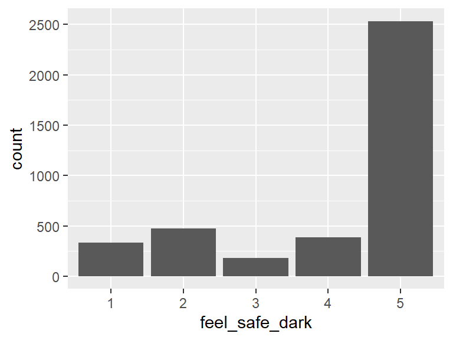

## community_lights

| Feature | Result |
| --- | --- |
| Variable type | character |
| Number of missing obs. | 0 (0 %) |
| Number of unique values | 6 |
| Mode | “no” |

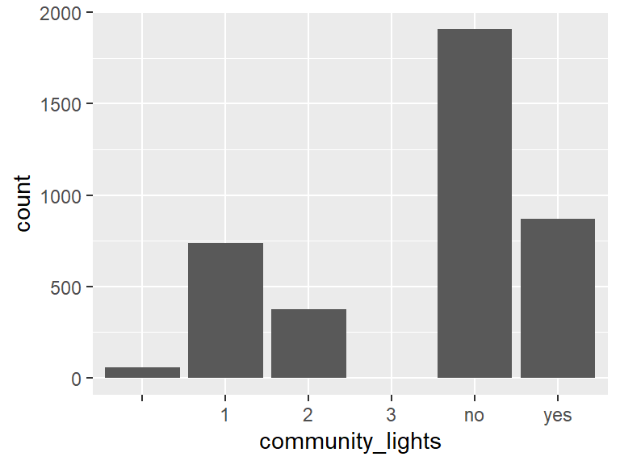

- The following suspected missing value codes enter as regular values: "".
- Note that the following levels have at most five observations: "3".

## home_exterior_lights

- Note that this variable is treated as a factor variable below, as it only takes a few unique values.

| Feature | Result |
| --- | --- |
| Variable type | numeric |
| Number of missing obs. | 54 (1.37 %) |
| Number of unique values | 2 |
| Mode | “0” |
| Reference category | 0 |

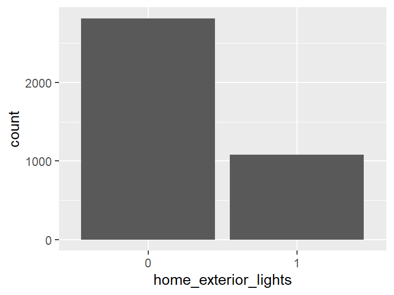

## feel_safe_if_exterior_lights

- Note that this variable is treated as a factor variable below, as it only takes a few unique values.

| Feature | Result |
| --- | --- |
| Variable type | numeric |
| Number of missing obs. | 14 (0.35 %) |
| Number of unique values | 5 |
| Mode | “1” |
| Reference category | 1 |

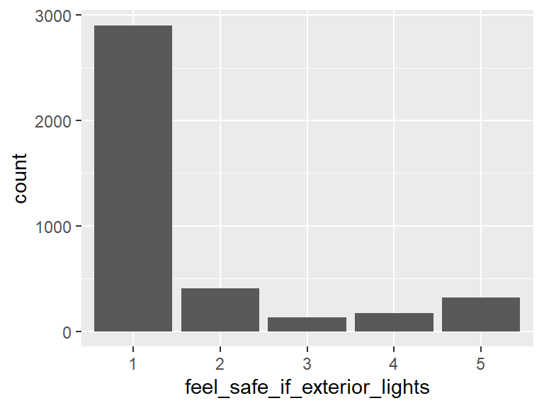

## feel_unsafe_reasons

| Feature | Result |
| --- | --- |
| Variable type | numeric |
| Number of missing obs. | 15 (0.38 %) |
| Number of unique values | 6 |
| Median | 3 |
| 1st and 3rd quartiles | 1; 4 |
| Min. and max. | 1; 6 |

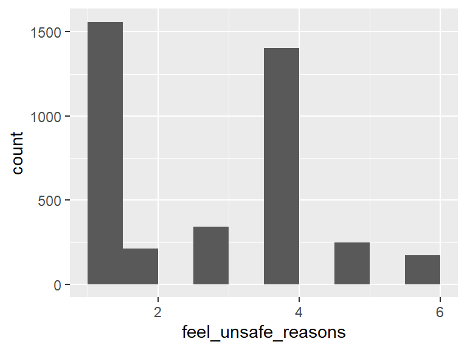

- Note that the following possible outlier values were detected: "6".

## phone_charge_location

- Note that this variable is treated as a factor variable below, as it only takes a few unique values.

| Feature | Result |
| --- | --- |
| Variable type | numeric |
| Number of missing obs. | 43 (1.09 %) |
| Number of unique values | 4 |
| Mode | “1” |
| Reference category | 1 |

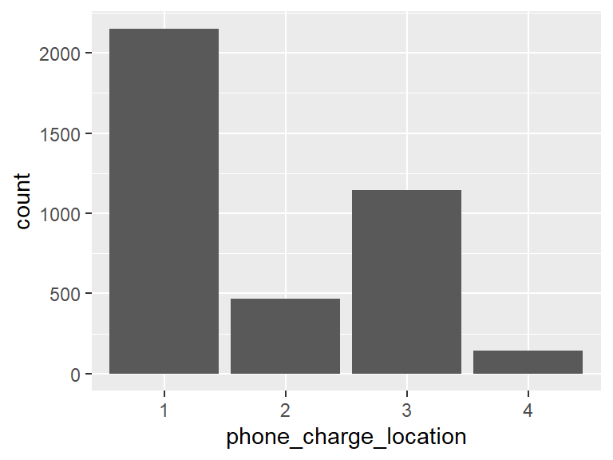

## phone_charge_frequency

- Note that this variable is treated as a factor variable below, as it only takes a few unique values.

| Feature | Result |
| --- | --- |
| Variable type | numeric |
| Number of missing obs. | 113 (2.86 %) |
| Number of unique values | 4 |
| Mode | “1” |
| Reference category | 1 |

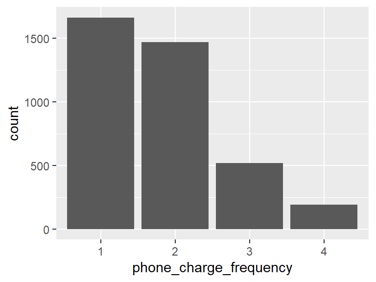

## phone_charge_cost

| Feature | Result |
| --- | --- |
| Variable type | character |
| Number of missing obs. | 0 (0 %) |
| Number of unique values | 7 |
| Mode | “2” |

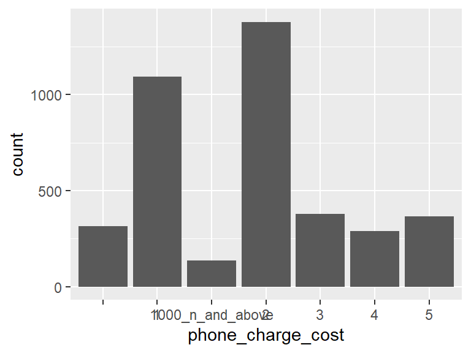

- The following suspected missing value codes enter as regular values: "".

## phone_charge_travel_distance

- Note that this variable is treated as a factor variable below, as it only takes a few unique values.

| Feature | Result |
| --- | --- |
| Variable type | numeric |
| Number of missing obs. | 334 (8.45 %) |
| Number of unique values | 5 |
| Mode | “2” |
| Reference category | 2 |

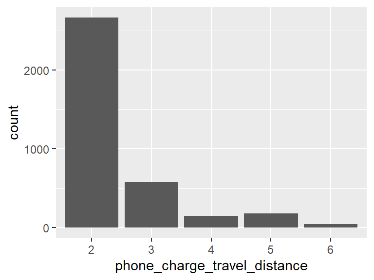

## water_source

| Feature | Result |
| --- | --- |
| Variable type | character |
| Number of missing obs. | 0 (0 %) |
| Number of unique values | 6 |
| Mode | “2” |

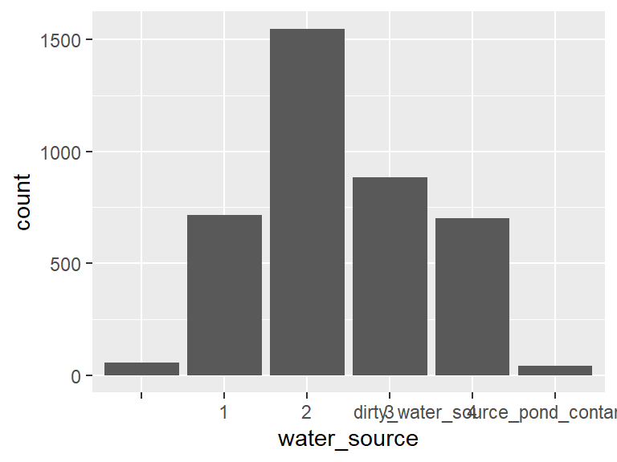

- The following suspected missing value codes enter as regular values: "".

## clean_drinking_water

- Note that this variable is treated as a factor variable below, as it only takes a few unique values.

| Feature | Result |
| --- | --- |
| Variable type | numeric |
| Number of missing obs. | 137 (3.47 %) |
| Number of unique values | 2 |
| Mode | “0” |
| Reference category | 0 |

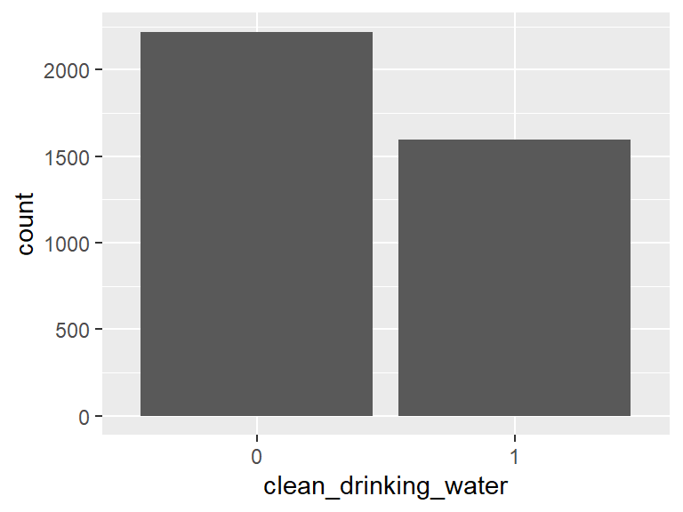

## clean_drinking_water_source

- Note that this variable is treated as a factor variable below, as it only takes a few unique values.

| Feature | Result |
| --- | --- |
| Variable type | numeric |
| Number of missing obs. | 1632 (41.3 %) |
| Number of unique values | 4 |
| Mode | “4” |
| Reference category | 1 |

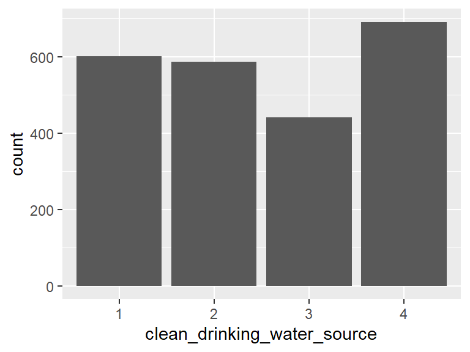

## clean_water_source

| Feature | Result |
| --- | --- |
| Variable type | character |
| Number of missing obs. | 0 (0 %) |
| Number of unique values | 27 |
| Mode | “” |

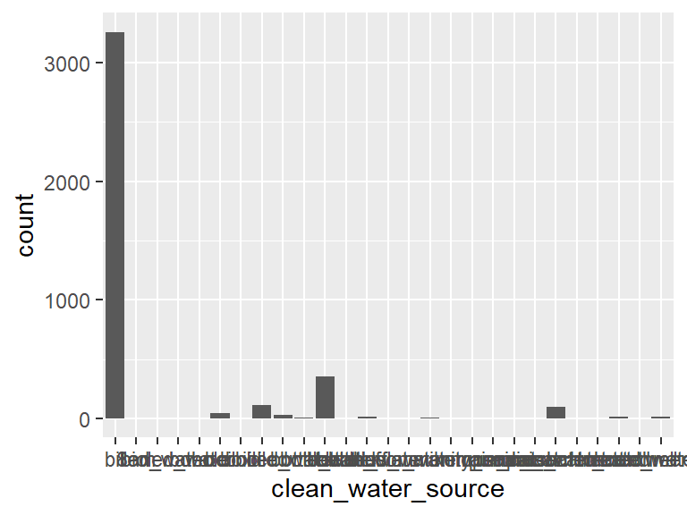

- The following suspected missing value codes enter as regular values: "".
- Note that the following levels have at most five observations: "8am", "billed_water", "bioled_water", "bohole", "boild", …, "purchase", "rain_catchmemt", "rain_catchnent", "rain_water_catchment", "treated_water" (7 values omitted).

## water_collection_travel_distance

- Note that this variable is treated as a factor variable below, as it only takes a few unique values.

| Feature | Result |
| --- | --- |
| Variable type | numeric |
| Number of missing obs. | 354 (8.96 %) |
| Number of unique values | 5 |
| Mode | “1” |
| Reference category | 1 |

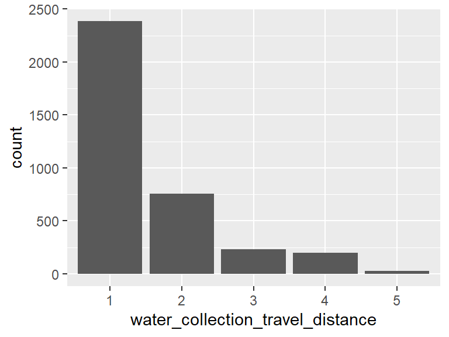

## water_collection_time

- Note that this variable is treated as a factor variable below, as it only takes a few unique values.

| Feature | Result |
| --- | --- |
| Variable type | numeric |
| Number of missing obs. | 402 (10.17 %) |
| Number of unique values | 5 |
| Mode | “1” |
| Reference category | 1 |

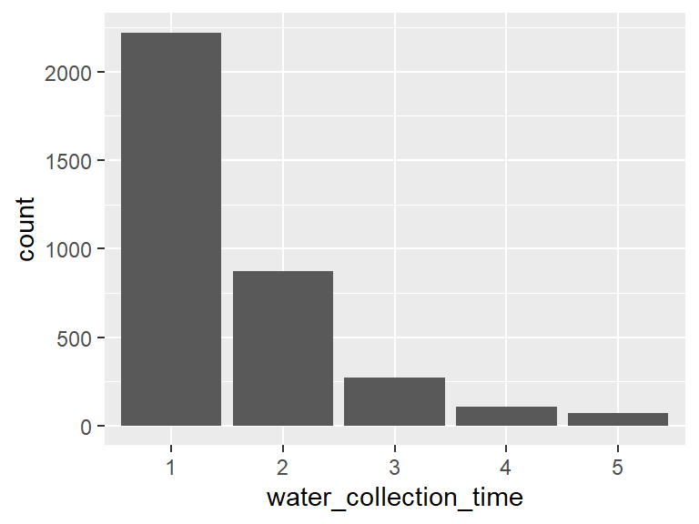

## water_collection_responsible

- Note that this variable is treated as a factor variable below, as it only takes a few unique values.

| Feature | Result |
| --- | --- |
| Variable type | numeric |
| Number of missing obs. | 372 (9.41 %) |
| Number of unique values | 4 |
| Mode | “2” |
| Reference category | 1 |

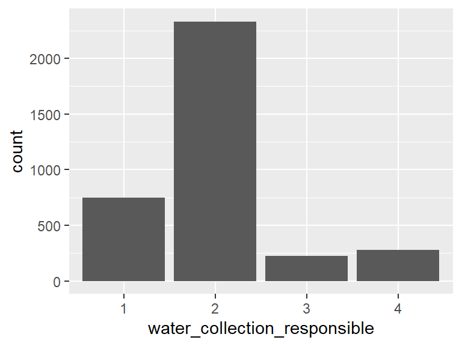

## avg_person_age_water_collection

| Feature | Result |
| --- | --- |
| Variable type | numeric |
| Number of missing obs. | 444 (11.23 %) |
| Number of unique values | 6 |
| Median | 5 |
| 1st and 3rd quartiles | 5; 5 |
| Min. and max. | 1; 6 |

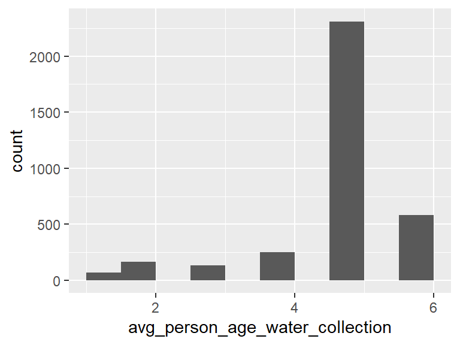

- Note that the following possible outlier values were detected: "1", "2", "3", "4", "6".

## water_cost

| Feature | Result |
| --- | --- |
| Variable type | character |
| Number of missing obs. | 0 (0 %) |
| Number of unique values | 7 |
| Mode | “i_dont_pay_its_free.” |

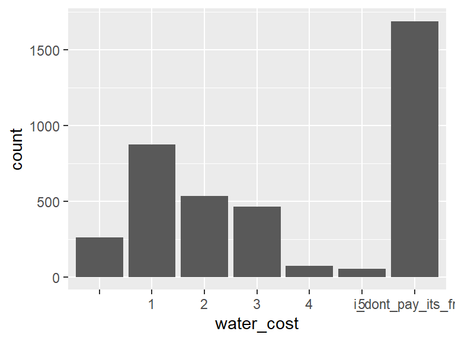

- The following suspected missing value codes enter as regular values: "".

## other_household_activities

| Feature | Result |
| --- | --- |
| Variable type | character |
| Number of missing obs. | 0 (0 %) |
| Number of unique values | 85 |
| Mode | “processing_ugaligari;” |

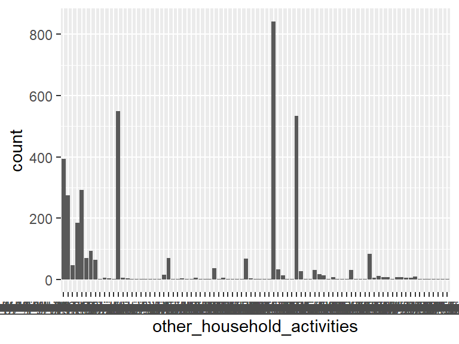

- The following suspected missing value codes enter as regular values: "".
- Note that the following levels have at most five observations: "hair_cuttingsalon;other_food_processing;processing_ugaligari;", "hair_cuttingsalon;processing_ugaligari;other_food_processing;", "hair_cuttingsalon;sewing;processing_ugaligari;", "other_food_processing;hair_cuttingsalon;", "other_food_processing;hair_cuttingsalon;processing_ugaligari;", …, "sewing;other_food_processing;processing_ugaligari;processing_alcohols;", "sewing;processing_ugaligari;", "sewing;processing_ugaligari;hair_cuttingsalon;", "sewing;processing_ugaligari;other_food_processing;", "sewing;processing_ugaligari;processing_palm_oil;" (40 values omitted).

## clinic_travel_distance

- Note that this variable is treated as a factor variable below, as it only takes a few unique values.

| Feature | Result |
| --- | --- |
| Variable type | numeric |
| Number of missing obs. | 2074 (52.48 %) |
| Number of unique values | 5 |
| Mode | “1” |
| Reference category | 1 |

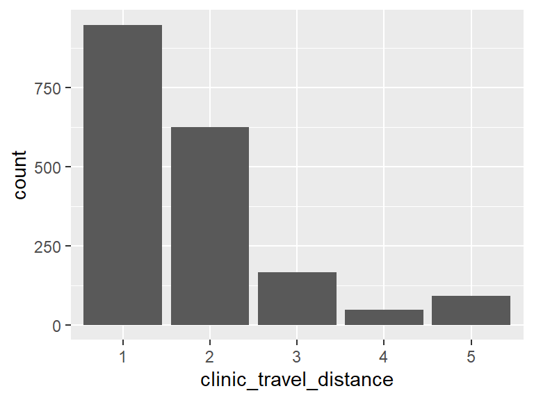

## clinic_electricity_access

- Note that this variable is treated as a factor variable below, as it only takes a few unique values.

| Feature | Result |
| --- | --- |
| Variable type | numeric |
| Number of missing obs. | 2003 (50.68 %) |
| Number of unique values | 2 |
| Mode | “0” |
| Reference category | 0 |

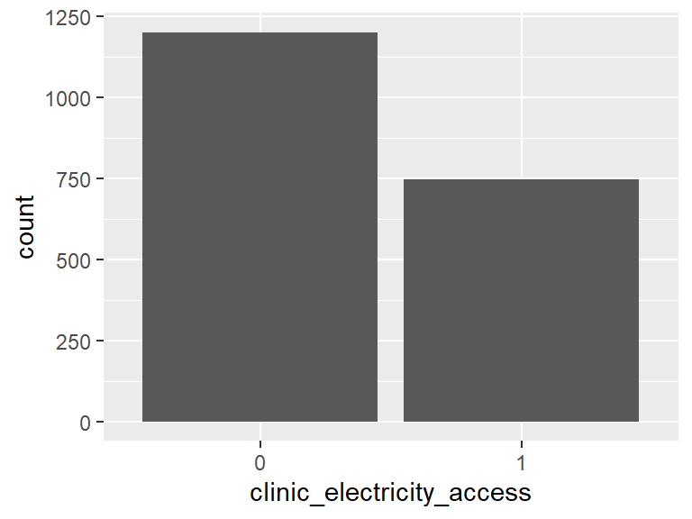

## clinic_refrigeration_access

- Note that this variable is treated as a factor variable below, as it only takes a few unique values.

| Feature | Result |
| --- | --- |
| Variable type | numeric |
| Number of missing obs. | 2016 (51.01 %) |
| Number of unique values | 2 |
| Mode | “0” |
| Reference category | 0 |

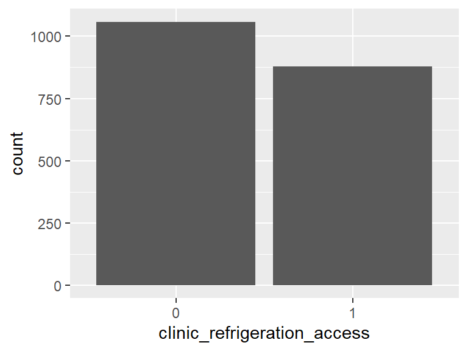

## end_date

| Feature | Result |
| --- | --- |
| Variable type | character |
| Number of missing obs. | 0 (0 %) |
| Number of unique values | 83 |
| Mode | “2021_06_29” |

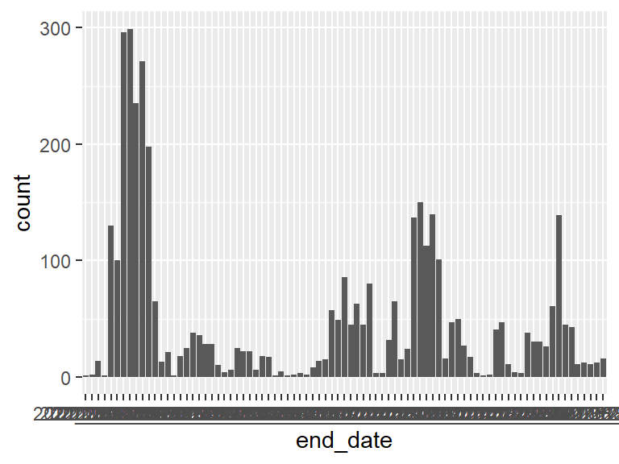

- Note that the following levels have at most five observations: "2021_06_09", "2021_06_23", "2021_06_25", "2021_07_08", "2021_08_10", …, "2021_11_22", "2021_11_26", "2021_11_29", "2021_12_06", "2021_12_08" (8 values omitted).

## customerAccountNumber

| Feature | Result |
| --- | --- |
| Variable type | integer |
| Number of missing obs. | 2948 (74.6 %) |
| Number of unique values | 949 |
| Median | 242205 |
| 1st and 3rd quartiles | 151167.5; 530138.5 |
| Min. and max. | 131110; 570190 |

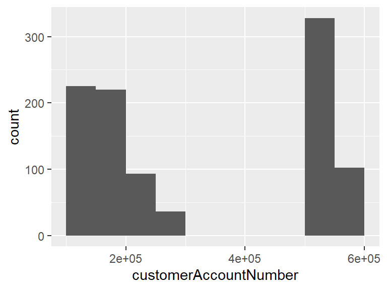